# Population Analysis

## Moshe, August 22, 2017

Population data are available from the [UN Population Reference Bureau](https://esa.un.org/unpd/wpp/Download/Standard/Population/). Their Total Population file tabulates "de facto population in a country, area or region as of 1 July of the year indicated". The current version covers 1950--2015. These data enable analysis of population growth for individual nations and total World population, as well as its breakup according to various classification criteria. For fun, start with a few individual nations.

## US

Modeling of the US population yields an excellent fit; the average deviation of model from data is 0.99%, the largest deviation (in 1963) is 2.67%. With a hindering parameter $H$ = 9.9, the US population growth is deeply in the hindered mode. Indeed, the hindering population is only $Q_h$ = 23 million while the 1950 population was 159 million, 7 times higher; the hindering threshold ($Q = Q_h$) was crossed long before 1950. The US population grows at the constant rate of 2.7 million per year, and it would actually make more sense to model it with the linear growth model since the hindered exponential model gives $r_u$ = 11.7%/yr. The model predicts a 2050 US population of 408 million.

## China

Similar to the US, the population of China has crossed the hindering threshold long before 1950. While modeling with hindered exponential growth fails, the straight linear growth model fits the data quite well: the average deviation of model from data is only 2.75%, the largest deviation (in 1963) only 5.57%. The model outcome is that the population of China is increasing by 14.3 million per year, having crossed the hindering threshold long before 1950. The model predicts that by 2050 the population of China will grow to 2 billion.

## India

The population of India has grown from 376 million in 1950 to 1.31 billion in 2015. The hindered growth model works pretty well--- the average deviation of model from data is 2.05%, the largest deviation (in 1967) is 4.21%. The model predicts a 2050 population of 2.3 billion, growing at 1.37%/yr. In contrast with the US and China, the hindering parameter is $H$ = 0.26 and the hindering population is $Q_h$ = 2.85 billion so that the hindering threshold $(Q = Q_h)$ will not be crossed even by 2050.

India is a interesting case where the hindering effect is significant even though its population will remain below the hindering threshold for sometime to come. Beginning in 1980 the growth rate shows a pronounced, steady downward trend (the figure bottom panel), therefore long-term model predictions could be an overestimate. The impliction is that in this case it might be prudent to add a quadtratic term to the hindering effect. Some further support for this conjecture comes from the fact that the model predicts a population increase of 71 million per year during the hindered growth phase; this is 5 times the rate for China, which might be hard to sustain for an extended period.

## World Population

Modeling of the total world population yields an almost perfect fit: the average deviation of model from data is 1.08%, the largest deviation (in 1963) is 2.64%. The hindering parameter is $H$ = 0.94, the hindering population is $Q_h$ = 4.83 billion and $Q = Q_h$ occurred in 1985. The model predictions for 2050 are a world population of 11 billion, adding 156 million per year for an annual growth rate of 0.98%. It would be interesting to extend the data to earlier years.

The spreadsheet breaks up the world population in different ways. Here's the analysis of the different components.

## Degree of Development

The criteria for classification by degree of development are

> More developed regions comprise Europe, Northern America, Australia/New Zealand and Japan. Less developed regions comprise all regions of Africa, Asia (except Japan), Latin America and the Caribbean plus Melanesia, Micronesia and Polynesia.

So it's really a geographic classification, rearranging the continents into two groups. This segmentation must be understood as applicable to whole regions not individual countries (except for Japan), otherwise it would lead to the curious (for me at least) result that Singapore and Taiwan are 'less developed' because they're in Asia while Albania and Moldova, being in Europe, are 'more developed'. Be that as it may, this is how they classify and we can analyze the population growth of each development class separately.

Below is a summary of the results. The summary figure shows the continuous decrease of the fractional population of the more developed regions. Every model of population classes must obey a 'unitarity' constraint: the sum of the populations of all classes must equal the world's population. The results, shown in the summary, indicate that the models pass the test: the deviations of the sum of models for more- and less-developed regions from the model for the entire world population are only 0.75% on average, with a maximum of 2.1%. Because these deviations are within the modeling errors (deviations of individual models from their corresponding data), the models are self-consistent.

## Continents

The classification by Continents is based (obviuosly) purely on location. In essence, it splits up each of the two development classes into three sub-classes. The model results fall in three groups. Similar to the case of more developed regions, both Europe and Northern America are fitted successfully by the linear growth model, and only by that model. This is not surprising---together they comprise the bulk of the more developed class, leaving out only Japan and Australia. The average deviations of model for data are 2.5% for Europe and 0.94% for Northern America. Notably, Europe's population is growing by only 2.85 million per year, predicted to rise from 741 million in 2015 to 872 million in 2050.

The second group comprises Oceania, Latin America and Asia. Each of these continents is fitted successfuly by the hindered growth model. For each member of this group, the following table columns show the average deviation of model from data, the hindering parameter $H$, the year the hindering threshold was crossed, the model prediction for the 2050 population and the annual population increase:

|  | avg err(%) | $H$ | $Q > Q_h$ | 2050 pop | growth |
| --- | --- | --- | --- | --- | --- |
| Oceania | 0.96 | 1.15 | 1973 | 57.3 million | $7.6\times10^5$ per year |
| Latin America | 1.31 | 2.29 | before 1950 | 950 million | $1.1\times10^7$ per year |
| Asia | 1.84 | 1.35 | 1967 | 6.67 billion | $8.3\times10^7$ per year |

In a group all by itself is Africa, whose population growth shows no signs of hindering---the hindering parameter is $H = 4.5\times10^{-9}$. A pure exponential with constant growth rate $r$ = 2.54%/yr gives an excellent fit, with model-from-data deviations of 1.55% on average and 3.66% maximum. If this growth is sustained through 2050, Africa's population will more than double from 1.2 billion in 2015 to 2.9 billion in 2050.

## Income Level

This is the most interesting and arguably the most meaningful of the classifications given. The classification has nothing to do with geography, instead it is based entirely on an objective, measurable indicator:

> The country classification by income level is based on 2016 GNI per capita from the World Bank.

All nations are binned into low-, middle- and high-income groups, which are all modeled successfuly. The results show that, as might be expected, income and population growth rate are inversely correlated: the models yield unhindered exponential growth for the low-income countries, hindered growth for the mid-income ones and linear growth, i.e., strongly hindered, for the high-income countries:

[output not shown]

Most of the world population resides in middle-income countries, as is evident from the results summary. The mid-income model most closely resembles that for the total world population, predicting an identical growth rate of 0.98%/yr in 2050. The summary figure shows an interesting result: beginning around 1990, **the fraction of the world population living in mid-income countries is almost constant at ~75-76% of total**. This is suggestive of the following speculative scenario: the income level rises globally so that some low-income nations move into the mid-income category while some mid-income ones are moving up to the high-income bin. The population growth rate of a nation decreases with the rising of its income level. For the mid-income bin, the competing effects of gaining population from the higher-growth-rate lower bin and losing population to the lower-growth-rate higher bin just balance each other so that its fraction of the total remains unchanged. For the low-income nations, the higher growth rate more than compensates for the loss of nations that move to the higher income bin, leading to a rising fractional population, with the opposite effect for high-income nations.

While plausible, this scenario cannot be tested with the current 'static' data because all nations are classified for all years according to their income level in one single year (2016). To verify the scenario we need 'dynamic' classification according to the income level in each year. It should be possible to get these data, which would make for an excellent follow-up project.

## To do

1. Would be good to extend the data to earlier years wherever possible.
2. The success in modeling populations probably stems from the smooth time variation of this quantity. Unlike the noisy variability of GDP growth rates, population growth rates are generally smooth, with 5-year rolling averages coinciding with the function itself, which is why they are not plotted. But the growth rates do show clear fluctuations around the model, which outlines the long-term variation of the data, with typical time scales of ~10 years, in contrast with the 1-year jittering of GDP growth rates. Would be good to devise a method to quantify the properties of the fluctuations, both amplitudes and characteristic time scales. Best would be if this could be done from the data alone without a specific model for the underlying long-term trends.

## Links:

US

China

India

World Population

Segmenting by Development

Checksum, Development

Segmenting by Continents

Checksum, Continents

Segmenting by Income

Checksum, Income

```python
import numpy as np
from numpy import exp, sqrt, log as ln, log10 as log
import matplotlib.pyplot as plt
import sys
sys.path.append('../Tools')
from ME_utils import *
from econ import *
from POP import *
```

Back to Top

# World Population

```
WORLD: 66 data points
Population has grown from 2.54E+09 in 1950 to 7.38E+09 in 2015
an increase by factor of 2.9

*** 2-parameter fit [ru, qh]:
 Initial guess --- None
 Final result  --- [3.230E+00, 1.905E+00]
*** Best-fit parameters:
   ru = 3.23%      unhindered (unsaturated) growth rate
   Qh = 4.83E+09   Hindering (saturation) population
   qh = Qh/Q0 = 1.91E+00
  Relative errors of fitting parameters:
   err(ru) = 3.97E-02
   err(Qh) = 8.64E-02
***Data covers a range of 2.10 growth times
***Hindering paramater H = 9.388E-01
   Hindering degree Qf/Qh = 1.53
   Hindering threshold (Q > Qh) crossed in 1985
   Hindered growth mode has a rate of 1.56E+08 per year
***Average deviation of model from data is 1.08%
   largest deviation of model from data is 2.64% in 1963

***Model predictions for 2050 for WORLD population:
   Population of 1.10E+10 and annual growth rate 0.98%

______________________________________________________________________
```

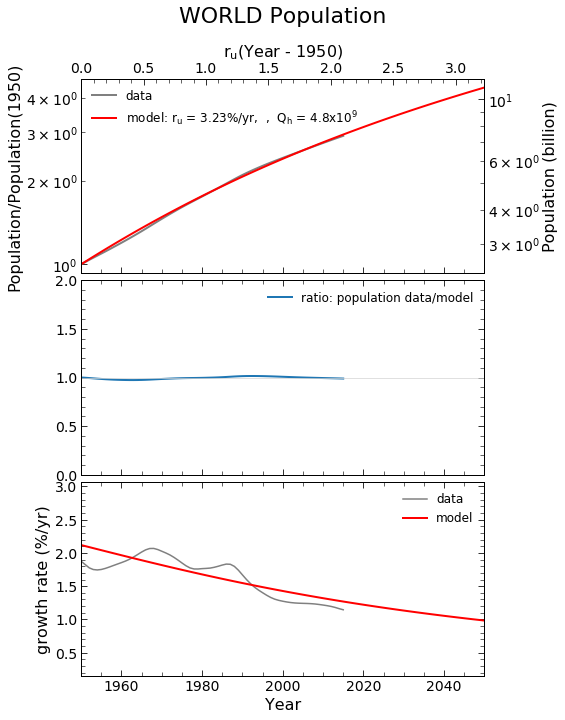

```python
Year   = np.arange(1950, 2016)
future = np.arange(1950, 2051)
plot_it = True

data_row = [18]
_, POP, models = POP_analyze(Year, future, data_row, plot_it)
World_pop = POP['WORLD']
World_model = models['WORLD']
```

Back to Top

# Segmenting by Development

```
More developed regions: 66 data points
Population has grown from 8.15E+08 in 1950 to 1.25E+09 in 2015
an increase by factor of 1.5

*** 2-parameter fit [ru, qh]:
 Initial guess --- None
Optimal parameters not found: The maximum number of function evaluations is exceeded.
Failed to fit the data for More developed regions

______________________________________________________________________

*** Attempting linear fit:
More developed regions: 66 data points
Population has grown from 8.15E+08 in 1950 to 1.25E+09 in 2015
an increase by factor of 1.5

*** Fitting with linear model:   Q = Q0*(1 + r0*t)
 Initial guess --- None
 Final result  --- [1.057E+00, 8.129E-03]
*** Best-fit parameters:
   r0 = 0.77 %/year    Q0 = 8.61E+08 2010USD
   Population increasses by 6.62E+06 per year
  Relative errors of fitting parameters:
   err(r0) = 6.23E-03   err(G0)= 2.15E-02
***Average deviation of model from data is 1.83%
   largest deviation of model from data is 5.35% in 1950

***Model predictions for 2050 for More developed regions population:
   Population of 1.52E+09 and annual growth rate 0.43%

______________________________________________________________________
```

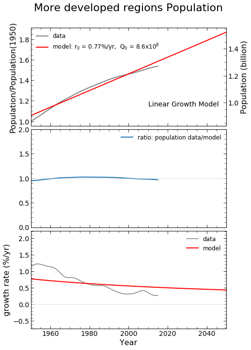

```
Less developed regions: 66 data points
Population has grown from 1.72E+09 in 1950 to 6.13E+09 in 2015
an increase by factor of 3.6

*** 2-parameter fit [ru, qh]:
 Initial guess --- None
 Final result  --- [3.467E+00, 2.691E+00]
*** Best-fit parameters:
   ru = 3.47%      unhindered (unsaturated) growth rate
   Qh = 4.63E+09   Hindering (saturation) population
   qh = Qh/Q0 = 2.69E+00
  Relative errors of fitting parameters:
   err(ru) = 3.42E-02
   err(Qh) = 8.55E-02
***Data covers a range of 2.25 growth times
***Hindering paramater H = 7.492E-01
   Hindering degree Qf/Qh = 1.32
   Hindering threshold (Q > Qh) crossed in 1996
   Hindered growth mode has a rate of 1.61E+08 per year
***Average deviation of model from data is 1.54%
   largest deviation of model from data is 3.98% in 1963

***Model predictions for 2050 for Less developed regions population:
   Population of 9.75E+09 and annual growth rate 1.12%

______________________________________________________________________
```

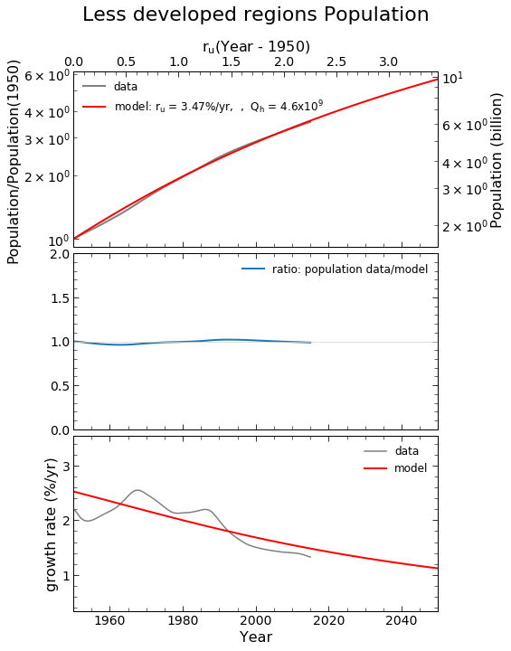

```python
data_row = [19, 20]
Regions, POP, models = POP_analyze(Year, future, data_row, plot_it)
```

Back to Top

# Summary, Development

```
1950 populations in billions:

                                 pop     % of tot
World                           2.54
More developed regions          0.81     32.13
Less developed regions          1.72     67.87
_______________________________________________
                  sum:          2.54     100.0

2015 populations in billions:

                                 pop     % of tot
World                           7.38
More developed regions          1.25     16.97
Less developed regions          6.13     83.03
_______________________________________________
                  sum:          7.38     100.0


Predictions for 2050 populations (billions):

                                 pop     % of tot
World                          11.04
More developed regions          1.52     13.80
Less developed regions          9.75     88.34
_______________________________________________
                  sum:         11.27     102.1

Deviations of population sums from total:
   Data(1950--2015)   -- average of 2E-15 percent, maximum 1.3E-13 percent
   Models(1950--2050) -- average of 0.75 percent, maximum 2.1 percent
```

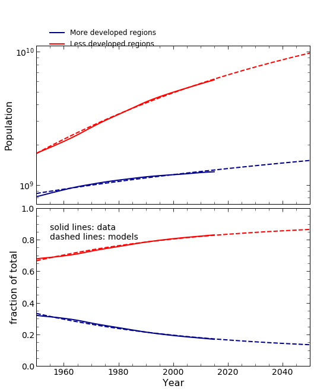

```python
check_sum(World_pop, World_model, Regions, POP, models, Year, future)
```

Back to Top

# Segmenting by Income

```
Low-income countries: 66 data points
Population has grown from 1.28E+08 in 1950 to 6.42E+08 in 2015
an increase by factor of 5

*** 2-parameter fit [ru, qh]:
 Initial guess --- None
 Final result  --- [2.424E+00, 2.169E+08]
*** Best-fit parameters:
   ru = 2.42%      unhindered (unsaturated) growth rate
   Qh = 2.78E+16   Hindering (saturation) population
   qh = Qh/Q0 = 2.17E+08
  Relative errors of fitting parameters:
   err(ru) = 3.47E-03
   err(Qh) = 3.63E-27
***Data covers a range of 1.58 growth times
***Hindering paramater H = 1.148E-08
   Hindering degree Qf/Qh = 2.31E-08
***Average deviation of model from data is 3.82%
   largest deviation of model from data is 6.16% in 1966

***Model predictions for 2050 for Low-income countries population:
   Population of 1.45E+09 and annual growth rate 2.42%

______________________________________________________________________
```

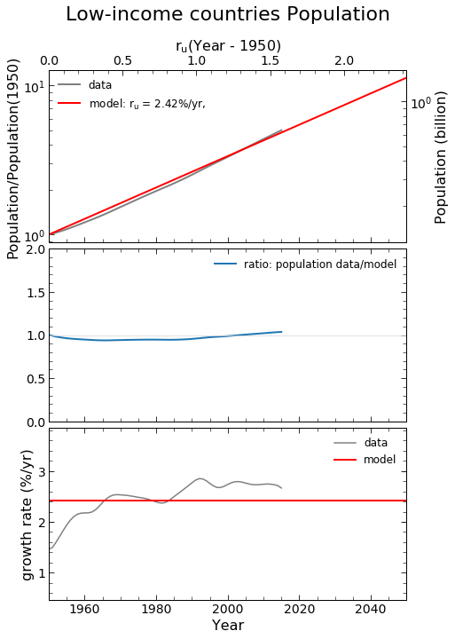

```
High-income countries: 66 data points
Population has grown from 6.73E+08 in 1950 to 1.18E+09 in 2015
an increase by factor of 1.8

*** 2-parameter fit [ru, qh]:
 Initial guess --- None
Optimal parameters not found: The maximum number of function evaluations is exceeded.
Failed to fit the data for High-income countries

______________________________________________________________________

*** Attempting linear fit:
High-income countries: 66 data points
Population has grown from 6.73E+08 in 1950 to 1.18E+09 in 2015
an increase by factor of 1.8

*** Fitting with linear model:   Q = Q0*(1 + r0*t)
 Initial guess --- None
 Final result  --- [1.023E+00, 1.147E-02]
*** Best-fit parameters:
   r0 = 1.12 %/year    Q0 = 6.89E+08 2010USD
   Population increasses by 7.72E+06 per year
  Relative errors of fitting parameters:
   err(r0) = 2.77E-03   err(G0)= 6.57E-03
***Average deviation of model from data is 0.76%
   largest deviation of model from data is 2.27% in 1950

***Model predictions for 2050 for High-income countries population:
   Population of 1.46E+09 and annual growth rate 0.53%

______________________________________________________________________
```

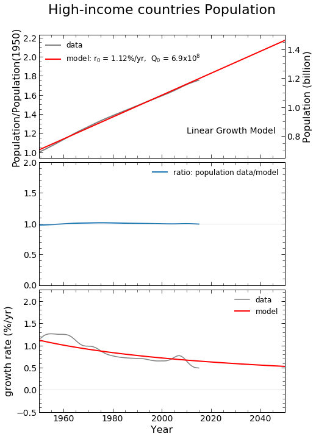

```
Middle-income countries: 66 data points
Population has grown from 1.73E+09 in 1950 to 5.56E+09 in 2015
an increase by factor of 3.2

*** 2-parameter fit [ru, qh]:
 Initial guess --- None
 Final result  --- [4.122E+00, 1.513E+00]
*** Best-fit parameters:
   ru = 4.12%      unhindered (unsaturated) growth rate
   Qh = 2.62E+09   Hindering (saturation) population
   qh = Qh/Q0 = 1.51E+00
  Relative errors of fitting parameters:
   err(ru) = 6.05E-02
   err(Qh) = 1.14E-01
***Data covers a range of 2.68 growth times
***Hindering paramater H = 1.251E+00
   Hindering degree Qf/Qh = 2.12
   Hindering threshold (Q > Qh) crossed in 1970
   Hindered growth mode has a rate of 1.08E+08 per year
***Average deviation of model from data is 1.69%
   largest deviation of model from data is 3.98% in 1963

***Model predictions for 2050 for Middle-income countries population:
   Population of 8.41E+09 and annual growth rate 0.98%

______________________________________________________________________
```

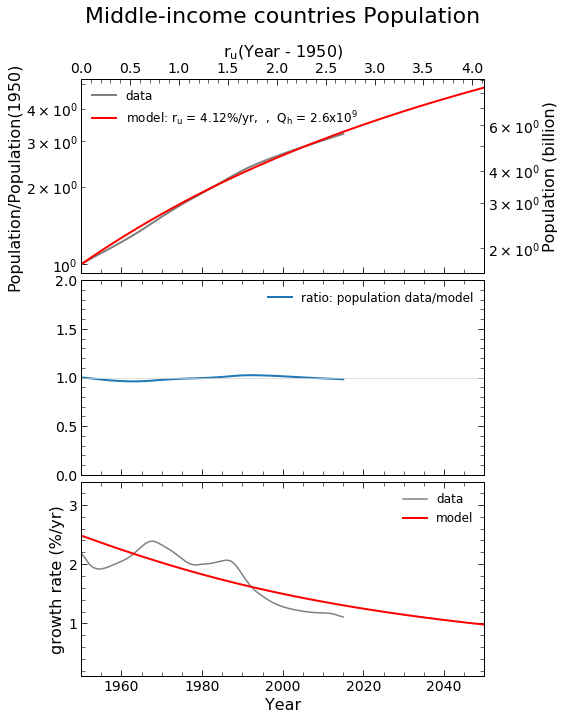

```python
data_row = [24, 25, 28]
Regions, POP, models = POP_analyze(Year, future, data_row, plot_it)
```

Back to Top

# Summary, Income

```
1950 populations in billions:

                                 pop     % of tot
World                           2.54
Low-income countries            0.13      5.05
High-income countries           0.67     26.53
Middle-income countries         1.73     68.39
_______________________________________________
                  sum:          2.54     100.0

2015 populations in billions:

                                 pop     % of tot
World                           7.38
Low-income countries            0.64      8.69
High-income countries           1.18     15.98
Middle-income countries         5.56     75.28
_______________________________________________
                  sum:          7.38     100.0


Predictions for 2050 populations (billions):

                                 pop     % of tot
World                          11.04
Low-income countries            1.45     13.11
High-income countries           1.46     13.23
Middle-income countries         8.41     76.20
_______________________________________________
                  sum:         11.32     102.5

Deviations of population sums from total:
   Data(1950--2015)   -- average of 0.036 percent, maximum 0.039 percent
   Models(1950--2050) -- average of 0.49 percent, maximum 2.5 percent
```

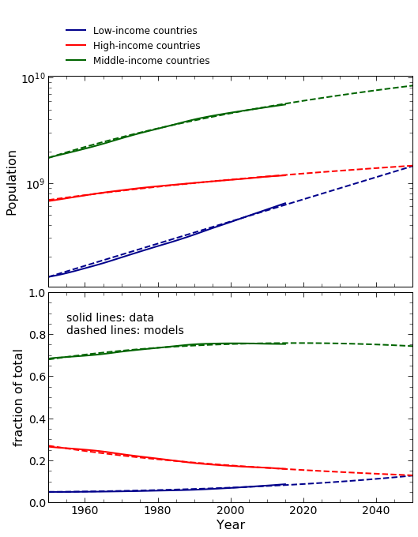

```python
check_sum(World_pop, World_model, Regions, POP, models, Year, future)
```

Back to Top

# Segmenting by Continents

```
EUROPE: 66 data points
Population has grown from 5.49E+08 in 1950 to 7.41E+08 in 2015
an increase by factor of 1.3

*** 2-parameter fit [ru, qh]:
 Initial guess --- None
Optimal parameters not found: The maximum number of function evaluations is exceeded.
Failed to fit the data for EUROPE

______________________________________________________________________

*** Attempting linear fit:
EUROPE: 66 data points
Population has grown from 5.49E+08 in 1950 to 7.41E+08 in 2015
an increase by factor of 1.3

*** Fitting with linear model:   Q = Q0*(1 + r0*t)
 Initial guess --- None
 Final result  --- [1.069E+00, 5.183E-03]
*** Best-fit parameters:
   r0 = 0.48 %/year    Q0 = 5.87E+08 2010USD
   Population increasses by 2.85E+06 per year
  Relative errors of fitting parameters:
   err(r0) = 7.96E-03   err(G0)= 4.36E-02
***Average deviation of model from data is 2.52%
   largest deviation of model from data is 6.48% in 1950

***Model predictions for 2050 for EUROPE population:
   Population of 8.72E+08 and annual growth rate 0.33%

______________________________________________________________________
```

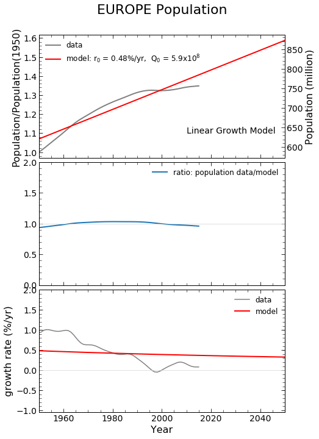

```
OCEANIA: 66 data points
Population has grown from 1.26E+07 in 1950 to 3.95E+07 in 2015
an increase by factor of 3.1

*** 2-parameter fit [ru, qh]:
 Initial guess --- None
 Final result  --- [3.684E+00, 1.625E+00]
*** Best-fit parameters:
   ru = 3.68%      unhindered (unsaturated) growth rate
   Qh = 2.06E+07   Hindering (saturation) population
   qh = Qh/Q0 = 1.63E+00
  Relative errors of fitting parameters:
   err(ru) = 4.47E-02
   err(Qh) = 8.87E-02
***Data covers a range of 2.39 growth times
***Hindering paramater H = 1.148E+00
   Hindering degree Qf/Qh = 1.92
   Hindering threshold (Q > Qh) crossed in 1973
   Hindered growth mode has a rate of 7.57E+05 per year
***Average deviation of model from data is 0.96%
   largest deviation of model from data is 2.76% in 1971

***Model predictions for 2050 for OCEANIA population:
   Population of 5.73E+07 and annual growth rate 0.97%

______________________________________________________________________
```

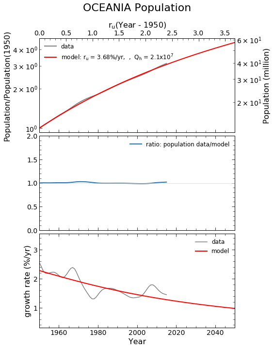

```
LATIN AMERICA AND THE CARIBBEAN: 66 data points
Population has grown from 1.69E+08 in 1950 to 6.32E+08 in 2015
an increase by factor of 3.7

*** 2-parameter fit [ru, qh]:
 Initial guess --- None
 Final result  --- [6.823E+00, 9.078E-01]
*** Best-fit parameters:
   ru = 6.82%      unhindered (unsaturated) growth rate
   Qh = 1.53E+08   Hindering (saturation) population
   qh = Qh/Q0 = 9.08E-01
  Relative errors of fitting parameters:
   err(ru) = 5.41E-02
   err(Qh) = 8.08E-02
***Data covers a range of 4.43 growth times
***Hindering paramater H = 2.289E+00
   Hindering degree Qf/Qh = 4.12
   Hindering threshold (Q > Qh) was crossed before 1950
   Hindered growth mode has a rate of 1.05E+07 per year
***Average deviation of model from data is 1.31%
   largest deviation of model from data is 2.93% in 1960

***Model predictions for 2050 for LATIN AMERICA AND THE CARIBBEAN population:
   Population of 9.50E+08 and annual growth rate 0.95%

______________________________________________________________________
```

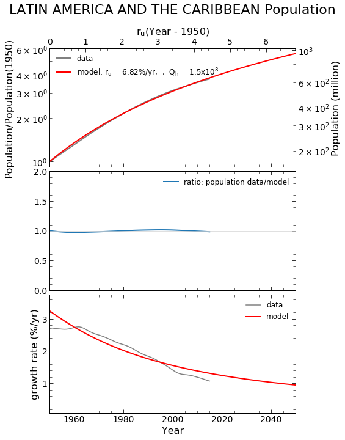

```
AFRICA: 66 data points
Population has grown from 2.29E+08 in 1950 to 1.19E+09 in 2015
an increase by factor of 5.2

*** 2-parameter fit [ru, qh]:
 Initial guess --- None
 Final result  --- [2.540E+00, 5.704E+08]
*** Best-fit parameters:
   ru = 2.54%      unhindered (unsaturated) growth rate
   Qh = 1.30E+17   Hindering (saturation) population
   qh = Qh/Q0 = 5.70E+08
  Relative errors of fitting parameters:
   err(ru) = 1.18E-03
   err(Qh) = 9.98E-29
***Data covers a range of 1.65 growth times
***Hindering paramater H = 4.479E-09
   Hindering degree Qf/Qh = 9.16E-09
***Average deviation of model from data is 1.55%
   largest deviation of model from data is 3.66% in 1966

***Model predictions for 2050 for AFRICA population:
   Population of 2.90E+09 and annual growth rate 2.54%

______________________________________________________________________
```

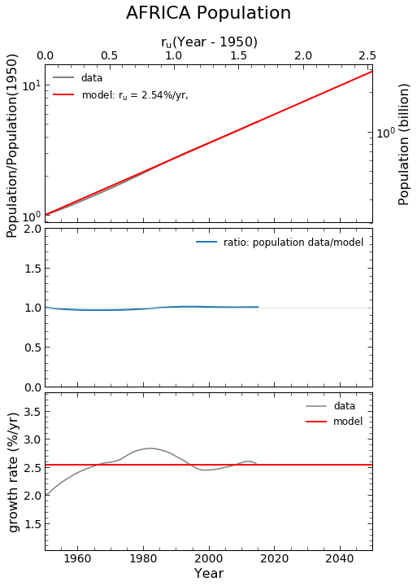

```
ASIA: 66 data points
Population has grown from 1.40E+09 in 1950 to 4.42E+09 in 2015
an increase by factor of 3.1

*** 2-parameter fit [ru, qh]:
 Initial guess --- None
 Final result  --- [4.260E+00, 1.388E+00]
*** Best-fit parameters:
   ru = 4.26%      unhindered (unsaturated) growth rate
   Qh = 1.95E+09   Hindering (saturation) population
   qh = Qh/Q0 = 1.39E+00
  Relative errors of fitting parameters:
   err(ru) = 7.17E-02
   err(Qh) = 1.31E-01
***Data covers a range of 2.77 growth times
***Hindering paramater H = 1.349E+00
   Hindering degree Qf/Qh = 2.27
   Hindering threshold (Q > Qh) crossed in 1967
   Hindered growth mode has a rate of 8.31E+07 per year
***Average deviation of model from data is 1.84%
   largest deviation of model from data is 4.68% in 1963

***Model predictions for 2050 for ASIA population:
   Population of 6.67E+09 and annual growth rate 0.96%

______________________________________________________________________
```

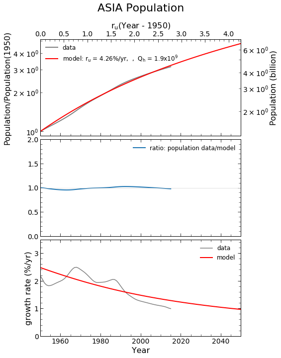

```
NORTHERN AMERICA: 66 data points
Population has grown from 1.73E+08 in 1950 to 3.56E+08 in 2015
an increase by factor of 2.1

*** 2-parameter fit [ru, qh]:
 Initial guess --- None
Optimal parameters not found: The maximum number of function evaluations is exceeded.
Failed to fit the data for NORTHERN AMERICA

______________________________________________________________________

*** Attempting linear fit:
NORTHERN AMERICA: 66 data points
Population has grown from 1.73E+08 in 1950 to 3.56E+08 in 2015
an increase by factor of 2.1

*** Fitting with linear model:   Q = Q0*(1 + r0*t)
 Initial guess --- None
 Final result  --- [1.009E+00, 1.599E-02]
*** Best-fit parameters:
   r0 = 1.58 %/year    Q0 = 1.74E+08 2010USD
   Population increasses by 2.76E+06 per year
  Relative errors of fitting parameters:
   err(r0) = 3.88E-03   err(G0)= 6.49E-03
***Average deviation of model from data is 0.94%
   largest deviation of model from data is 1.95% in 1964

***Model predictions for 2050 for NORTHERN AMERICA population:
   Population of 4.50E+08 and annual growth rate 0.61%

______________________________________________________________________
```

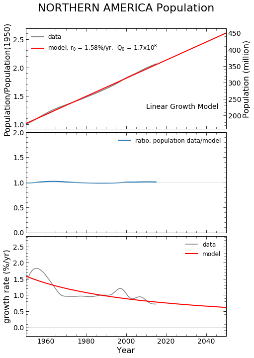

```python
data_row = [30, 94, 152, 205, 257, 263]
Regions, POP, models = POP_analyze(Year, future, data_row, plot_it)
```

Back to Top

# Summary, Continents

```
1950 populations in billions:

                                 pop     % of tot
World                           2.54
EUROPE                          0.55     21.66
OCEANIA                         0.01      0.50
LATIN AMERICA AND THE CAR       0.17      6.66
AFRICA                          0.23      9.02
ASIA                            1.40     55.36
NORTHERN AMERICA                0.17      6.81
_______________________________________________
                  sum:          2.54     100.0

2015 populations in billions:

                                 pop     % of tot
World                           7.38
EUROPE                          0.74     10.03
OCEANIA                         0.04      0.54
LATIN AMERICA AND THE CAR       0.63      8.57
AFRICA                          1.19     16.18
ASIA                            4.42     59.87
NORTHERN AMERICA                0.36      4.82
_______________________________________________
                  sum:          7.38     100.0


Predictions for 2050 populations (billions):

                                 pop     % of tot
World                          11.04
EUROPE                          0.87      7.90
OCEANIA                         0.06      0.52
LATIN AMERICA AND THE CAR       0.95      8.61
AFRICA                          2.90     26.26
ASIA                            6.67     60.45
NORTHERN AMERICA                0.45      4.08
_______________________________________________
                  sum:         11.90     107.8

Deviations of population sums from total:
   Data(1950--2015)   -- average of 2E-15 percent, maximum 1.3E-13 percent
   Models(1950--2050) -- average of 1.5 percent, maximum 7.3 percent
```

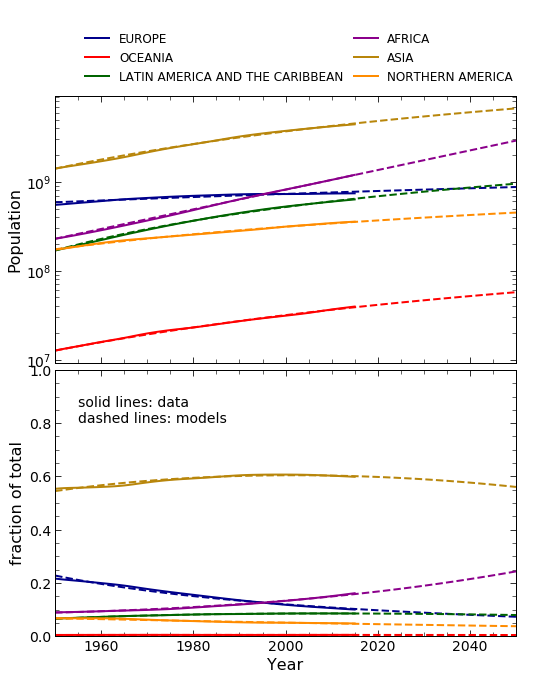

```python
check_sum(World_pop, World_model, Regions, POP, models, Year, future)
```

Back to Top

# US

```
United States of America: 66 data points
Population has grown from 1.59E+08 in 1950 to 3.20E+08 in 2015
an increase by factor of 2

*** 2-parameter fit [ru, qh]:
 Initial guess --- None
 Final result  --- [1.169E+01, 1.463E-01]
*** Best-fit parameters:
   ru = 11.69%      unhindered (unsaturated) growth rate
   Qh = 2.32E+07   Hindering (saturation) population
   qh = Qh/Q0 = 1.46E-01
  Relative errors of fitting parameters:
   err(ru) = 5.39E-01
   err(Qh) = 5.98E-01
***Data covers a range of 7.60 growth times
***Hindering paramater H = 9.899E+00
   Hindering degree Qf/Qh = 13.8
   Hindering threshold (Q > Qh) was crossed before 1950
   Hindered growth mode has a rate of 2.72E+06 per year
***Average deviation of model from data is 0.99%
   largest deviation of model from data is 2.67% in 1963

***Model predictions for 2050 for United States of America population:
   Population of 4.08E+08 and annual growth rate 0.63%

______________________________________________________________________
```

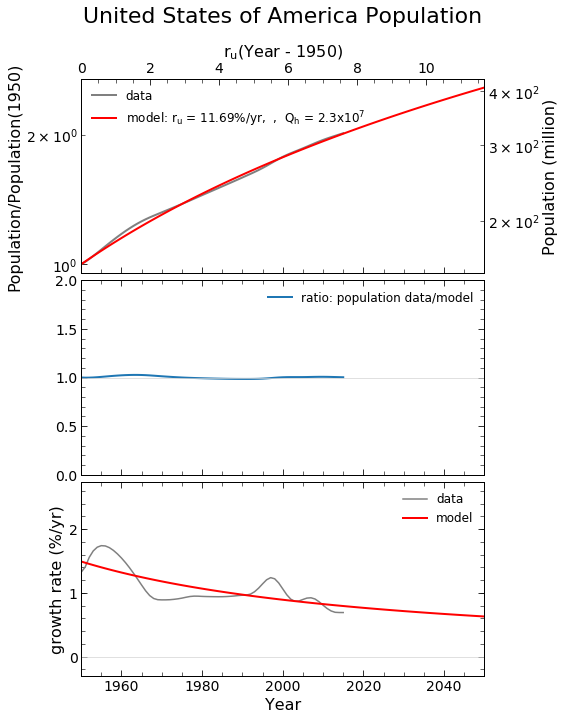

```python
data_row = [262]  # US
_, POP, models = POP_analyze(Year, future, data_row, plot_it)
```

Back to Top

# China

```
China: 66 data points
Population has grown from 5.54E+08 in 1950 to 1.40E+09 in 2015
an increase by factor of 2.5

*** 2-parameter fit [ru, qh]:
 Initial guess --- None
Optimal parameters not found: The maximum number of function evaluations is exceeded.
Failed to fit the data for China

______________________________________________________________________

*** Attempting linear fit:
China: 66 data points
Population has grown from 5.54E+08 in 1950 to 1.40E+09 in 2015
an increase by factor of 2.5

*** Fitting with linear model:   Q = Q0*(1 + r0*t)
 Initial guess --- None
 Final result  --- [9.875E-01, 2.576E-02]
*** Best-fit parameters:
   r0 = 2.61 %/year    Q0 = 5.48E+08 2010USD
   Population increasses by 1.43E+07 per year
  Relative errors of fitting parameters:
   err(r0) = 1.53E-02   err(G0)= 1.55E-02
***Average deviation of model from data is 2.75%
   largest deviation of model from data is 5.57% in 1963

***Model predictions for 2050 for China population:
   Population of 1.98E+09 and annual growth rate 0.72%

______________________________________________________________________
```

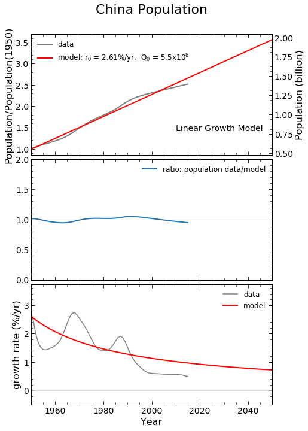

```python
data_row = [96]  # China
_, POP, models = POP_analyze(Year, future, data_row, plot_it)
```

Back to Top

# India

```
India: 66 data points
Population has grown from 3.76E+08 in 1950 to 1.31E+09 in 2015
an increase by factor of 3.5

*** 2-parameter fit [ru, qh]:
 Initial guess --- None
 Final result  --- [2.484E+00, 7.568E+00]
*** Best-fit parameters:
   ru = 2.48%      unhindered (unsaturated) growth rate
   Qh = 2.85E+09   Hindering (saturation) population
   qh = Qh/Q0 = 7.57E+00
  Relative errors of fitting parameters:
   err(ru) = 3.21E-02
   err(Qh) = 1.67E-01
***Data covers a range of 1.61 growth times
***Hindering paramater H = 2.627E-01
   Hindering degree Qf/Qh = 0.46
   Hindered growth mode has a rate of 7.07E+07 per year
***Average deviation of model from data is 2.05%
   largest deviation of model from data is 4.21% in 1967

***Model predictions for 2050 for India population:
   Population of 2.30E+09 and annual growth rate 1.37%

______________________________________________________________________
```

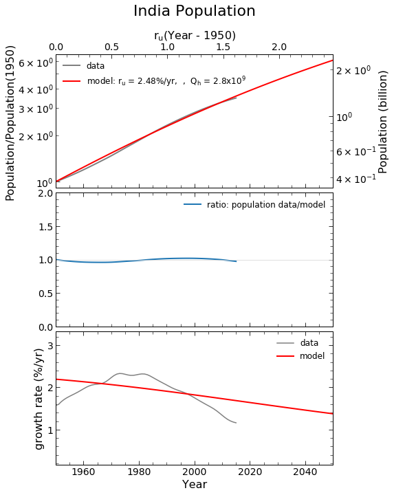

```python
data_row = [115] #India
_, POP, models = POP_analyze(Year, future, data_row, plot_it)
```

Back to Top